# PAC 2: Visualització de Dades

Lluís Manso Matachana

2026-10-19

# 1 Introducció

En aquesta pràctica s’ha creat tres visualitzacions, usant les següents tècniques assignades: Cartograms, Linear dendrogram i UpSet: Visualizing.

Per elaborar-les, s’han seleccionat conjunts de dades obertes adequats a les característiques de cada tècnica.

En el cartogram, s´ha treballat amb dades obertes d’Our World in Data sobre les emissions totals de CO2 per país l’any 2024, amb l’objectiu de representar visualment les diferències entre els principals emissors mundials.

En el upset:visualizing, s’han utilitzat dades d’Our World in Data sobre el consum d’energia per capita segons la font energètica als països de la Unió Europea l’any 2025, amb l’objectiu d’identificar patrons i interseccions entre les diferents fonts d’energia.

# 2 TÈCNICA GRUP I (Bàsiques y populars): Cartograms

Tal i com esmenta IBM (https://www.ibm.com/docs/es/cognos-analytics/11.2.x?topic=samples-cartogram-schematic), el cartograma és una tècnica de visualització geogràfica que modifica la mida o la forma de les àrees geogràfiques en funció d’una variable quantitativa, amb l’objectiu de representar visualment les diferències entre territoris.

Les aplicacions més habituals dels cartogrames inclouen: - visualitzacions demogràfiques - representacions electorals - indicadors socieconomics

Aquest tipus de visualitzacions requereix informació geogràfica associada als territoris i una variable quantitativa que permeti determinar la distorsió de les seves àrees.

Per això aquesta pràctica, s´ha decidit fer una tria d´un indicador ambiental quantitatiu com les emissions annuals de CO2 en un context geogràfic, amb l’objectiu de representar visualment les diferències entre els principals emissors mundials.

Per aquesta tècnica s´ha treballat amb la següent font: https://ourworldindata.org/co2-emissions.

El conjunt de dades utilitzat s´ha extret en format csv, i correspon a l’any 2024 amb un nombre total de 197 observacions.

El csv contè les següents variables:

- Entity: variable categòrica que identifica el país.
- Code: variable categòrica que identifica el codi del país.
- Year: variable numèrica que identifica l’any de les dades (2024).
- Annual CO2 emissions: variable numèrica que representa les emissions totals anuals de CO2 del país.

Per qüestions de disseny, s´ha decidit excloure l´Antàrtida, amb un valor de 0, per concentrar-se en totes aquells països o territoris i els seus valors corresponents.

Aquesta visualització s’adreça a un públic general interessat en el canvi climàtic i en les desigualtats territorials de les emissions.

```r
# Càrrega del csv
co2_annual_emissions <- read.csv("annual_co2_emissions.csv")
```

```r
# Reanomena la variable d´emssions CO2
co2_annual_emissions <- co2_annual_emissions %>%
  rename(co2_emissions = Annual.CO..emissions)

# Càrrega el mapa mundi
world <- ne_countries(
  scale = "medium",
  returnclass = "sf"
)
```

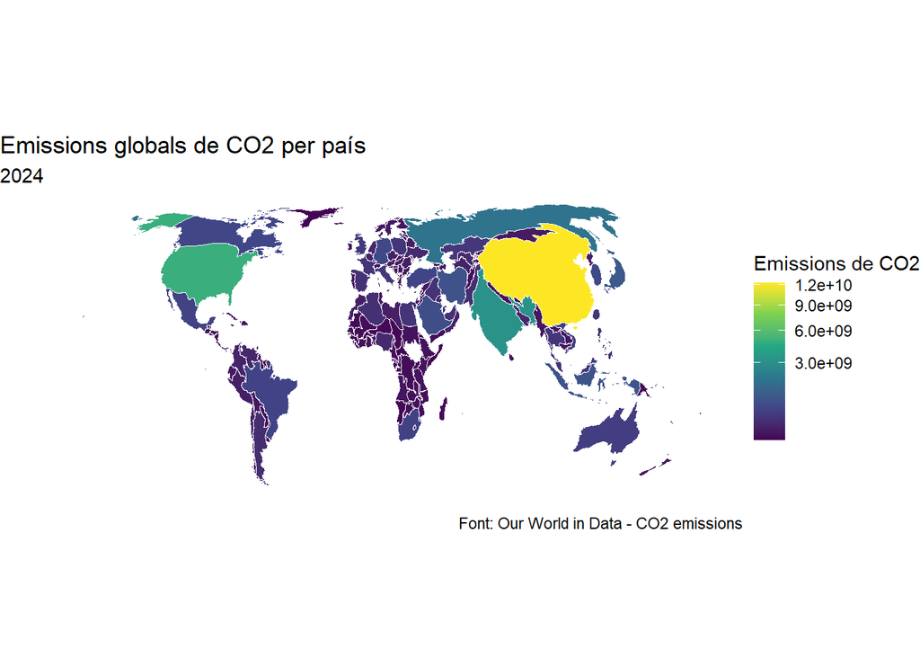

```r
# Associa codi amb la variable d´emissions CO2
world_co2 <- world %>%
  left_join(
    co2_annual_emissions,
    by = c("adm0_a3" = "Code")
  )

# Transforma el sistema de coordenades
world_co2 <- st_transform(world_co2, 8857)

# S´exclou dades que no estant disponibles i l´Antàrtida
world_co2 <- world_co2 %>%
  filter(!is.na(co2_emissions), iso_a3 != "ATA")

# Creació del cartograma
world_cartogram <- cartogram_cont(
  world_co2,
  weight = "co2_emissions",
  itermax = 5
)

# Representació del cartograma amb la llibreria ggplot
ggplot(world_cartogram) +
  geom_sf(aes(fill = co2_emissions),
          color = "white",
          linewidth = 0.2) +
  scale_fill_viridis_c(
    trans = "sqrt",
    name = "Emissions de CO2"
  ) +
  labs(
    title = "Emissions globals de CO2 per país",
    subtitle = "2024",
    caption = "Font: Our World in Data - CO2 emissions"
  ) +
  theme_void()
```

# 3 TÈCNICA GRUP II (Habituals i específiques): Linear dendrogram

Tal i com esmenta IBM (https://www.ibm.com/docs/en/spss-modeler/18.6.0?topic=types-dendrogram-charts), els dendrogrames són diagrames d’arbre que representen relacions jeràrquiques entre observacions. La seva estructura està formada per branques que connecten les observacions en funció del seu grau de semblança.

Les aplicacions més habituals dels linears dendrograms inclouen: - anàlisis de cluster - Segmentació de mercat o client - Biologia i genètica

Aquest tipus de visualització permet agrupar observacions a partir de variables quantitatives i representar-ne les semblances mitjançant una estructura jeràrquica. El resultat depèn de les variables seleccionades i del mètode de càlcul de distàncies i agrupament utilitzat.

Per això aquesta pràctica, s’ha seleccionat un conjunt de dades sobre els partits de la temporada 2025-2026 de la UEFA Champions League, amb l’objectiu d’identificar similituds entre els equips participants a partir de les seves estadístiques de joc.

Per aquesta tècnica s´ha treballat amb la següent font: https://www.kaggle.com/datasets/johntocci/champions-league-matches-2025-2026

El conjunt de dades utilitzat s´ha extret en format csv, i correspon a la temporada 2025/2026 amb un nombre total de 151 observacions i 17 variables.

Per construir el dendrograma i per qüestions de disseny visual, s’han transformat les dades originals per obtenir una observació per equip i calcular-ne les estadístiques mitjanes, independentment de si jugava com a local o visitant. Les variables utilitzades per establir les agrupacions són:

- gols_marcats: mitjana de gols marcats per partit.
- gols_rebuts: mitjana de gols encaixats per partit.
- possessio: mitjana del percentatge de possessió.
- precisio_xuts: mitjana del percentatge de xuts a porteria.
- parades: mitjana de parades del porter per partit.

Abans de calcular les distàncies, les variables numèriques s’han estandarditzat per facilitar-ne la comparació, i s’ha aplicat un mètode d’agrupament jeràrquic.

Aquesta visualització s’adreça a un públic general interessat en el fútbol i permet observar quins equips presenten perfils estadístics semblants durant la temporada 2025/2026.

```r
champions_league <- read.csv("champions_league_matches.csv")
```

```r
# Extreu els gols del marcador (score)
champions_preparada <- champions_league %>%
  separate(
    score,
    into = c("home_goals", "away_goals"),
    sep = "\u2013",
    convert = TRUE
  ) %>%
  mutate(
    home_possession = as.numeric(
      str_remove(home_possession, "%")
    ),
    away_possession = as.numeric(
      str_remove(away_possession, "%")
    ),
    home_saves = as.numeric(
      str_extract(home_saves, "^\\d+")
    ),
    away_saves = as.numeric(
      str_extract(away_saves, "^\\d+")
    )
  )
```

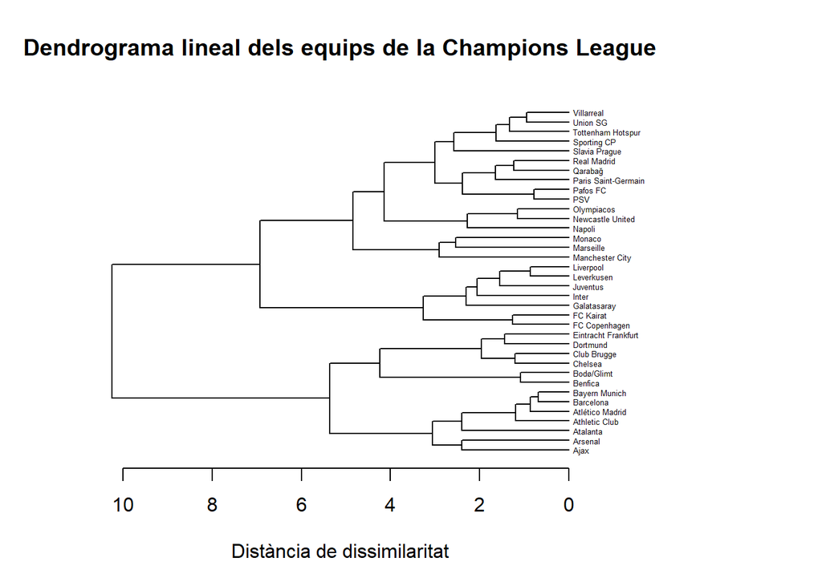

```r
# Crea una observació per a cada equip
equips_partits <- bind_rows(
  champions_preparada %>%
    transmute(
      team = home_team,
      goals_scored = home_goals,
      goals_conceded = away_goals,
      possession = home_possession,
      shots_pct = home_shots_on_target_pct,
      saves = home_saves
    ),
  champions_preparada %>%
    transmute(
      team = away_team,
      goals_scored = away_goals,
      goals_conceded = home_goals,
      possession = away_possession,
      shots_pct = away_shots_on_target_pct,
      saves = away_saves
    )
)

# Calcula les estadístiques mitjanes de cada equip
perfils_equips <- equips_partits %>%
  group_by(team) %>%
  summarise(
    partits = n(),
    gols_marcats = mean(goals_scored, na.rm = TRUE),
    gols_rebuts = mean(goals_conceded, na.rm = TRUE),
    possessio = mean(possession, na.rm = TRUE),
    precisio_xuts = mean(shots_pct, na.rm = TRUE),
    parades = mean(saves, na.rm = TRUE),
    .groups = "drop"
  )

# Selecciona les variables esmentades per comparar els equips
dades_equips <- perfils_equips %>%
  select(
    gols_marcats,
    gols_rebuts,
    possessio,
    precisio_xuts,
    parades
  )

# Conserva només els equips amb totes les dades
files_completes <- complete.cases(dades_equips)

dades_equips <- dades_equips[files_completes, ]

etiquetes_equips <- perfils_equips$team[files_completes]

# Estandarditza les variables
dades_equips_est <- scale(dades_equips)

# Calcula distàncies i clustering
distancies_equips <- dist(dades_equips_est)

clustering_equips <- hclust(
  distancies_equips,
  method = "ward.D2"
)

# Crea el dendrograma
dend_equips <- as.dendrogram(clustering_equips)

labels(dend_equips) <- etiquetes_equips

dend_equips <- dend_equips %>%
  set("labels_cex", 0.4)

# Representa visualment
par(mar = c(5, 4, 4, 10), xpd = TRUE)

plot(
  dend_equips,
  horiz = TRUE,
  main = "Dendrograma lineal dels equips de la Champions League",
  xlab = "Distància de dissimilaritat"
)
```

```r
par(xpd = FALSE)
```

# 4 TÉCNICA GRUP III (Menos habituals o específiques): UpSet: Visualizing Intersecting Sets

Tal i com esmenta National Center for Biotechnology Information (https://pmc.ncbi.nlm.nih.gov/articles/PMC4720993/), el Upset és una tècnica de visualització que representa les interseccions entre conjunts, mitjançant una matriu de punts i incorpora agregacions basades en agrupacions i consultes. Aquesta estructura permet representar de manera efectiva les interseccions entre conjunts, el nombre d’elements que contenen i altres estadístiques resum derivades dels atributs dels subconjunts o dels elements. A més, permet ordenar les interseccions segons diferents criteris per facilitar l’anàlisi i identificar les combinacions més rellevants.

Per això aquesta pràctica, ha decidit analitzar les interseccions entre tres conjunts de països de la Unió Europea-27, definits segons si el seu consum d’energia per capita procedent de combustibles fòssils, energia nuclear o energies renovables supera la mediana corresponent. L’objectiu és identificar les combinacions més freqüents i observar similituds en els perfils de consum energètic dels països analitzats.

Per aquesta tècnica s´ha treballat amb la següent font: https://ourworldindata.org/energy-mix

El conjunt de dades utilitzat s´ha extret en format csv, i correspon a l´any 2025 amb un nombre total de 26 observacions i 6 variables:

- Entity: variable categòrica que identifica el país.
- Code: variable categòrica que identifica el codi del país.
- Year: variable numèrica que identifica l’any de les dades (2025).
- Fossil fuels: variable numèrica que identifica el consumer per càpita de combustibles fòssils.
- Nuclear: variable numèrica que identifica el consumer per càpita d´energia nuclear.
- Renewables: variable numèrica que identifica el consumer per càpita d´energies renovables.

Aquest conjunt de dades de l´UE-27 ha presentat dues limitacions. La primera és que Malta no té informació disponible sobre el consum per càpita d´energia i per tant s´ha exclos de l´anàlisi. La segona, es que s´ha observat que Xipre té un NA en la font d´energia de combustibles fòssils. Per respectar la coherencia i la comparabilitat amb els altres països s´ha pres la decisió de disseny de també excluir aquest païs en l´anàlisi.

```r
# Càrrega del dataset
energymix_pcap <- read.csv("per_capita_energy_source.csv")

energymix_pcap[!complete.cases(energymix_pcap), ]
```

```
##   Entity Code Year Fossil.fuels Nuclear Renewables
## 5 Cyprus  CYP 2025           NA       0    1461.01
```

```r
# Excloure aquells països que no tenen dades disponibles com Xipre
energy_clean <- energymix_pcap %>%
  filter(complete.cases(Fossil.fuels, Nuclear, Renewables))

# Calcula les medianes
mediana_fossils <- median(energy_clean$Fossil.fuels)
mediana_nuclear <- median(energy_clean$Nuclear)
mediana_renewables <- median(energy_clean$Renewables)

# Estableix interseccions
energy_sets <- energy_clean %>%
  mutate(
    `Fossil fuels` = Fossil.fuels > mediana_fossils,
    Nuclear = Nuclear > mediana_nuclear,
    Renewables = Renewables > mediana_renewables
  )
```

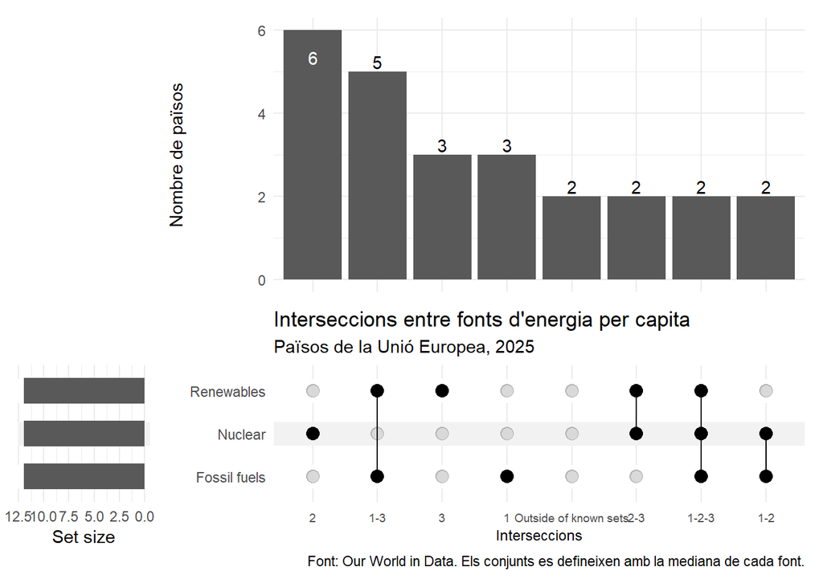

```r
# Creació del upset
upset(
  energy_sets,
  intersect = c("Fossil fuels", "Nuclear", "Renewables"),
  name = "Fonts d'energia",
  base_annotations = list(
    "Nombre de països" = intersection_size()
  ),
  width_ratio = 0.2
) +
  labs(
    title = "Interseccions entre fonts d'energia per capita",
    subtitle = "Països de la Unió Europea, 2025",
    x = "Interseccions",
    caption = "Font: Our World in Data. Els conjunts es defineixen amb la mediana de cada font."
  ) +
  theme(
    axis.text.x = element_text(size = 7),
    axis.title.x = element_text(size = 9)
  )
```